# Validating Philosophers’ Quotes on Joy Through Text Data

Jason Cho

2023-09-20

Dataset : HappyDB is a corpus of 100,000 crowd-sourced happy moments via Amazon’s Mechanical Turk. You can read more about it on https://arxiv.org/abs/1801.07746

In this data story, I have only used what I needed from HappyDB. I have subsetted the data to conduct data analysis.

I have cleaned the data by converting all the letters to the lower case, and removing punctuation, numbers, empty words and extra white space. I also added stop words after realizing the unnecessary words from generating the word clouds.

After exporting the processed data, I have combined the necessary data I will need for this data story. The data that I will be using will be cleaned_hm.csv and demographic.csv.I have merged the two, subsetting it for convenience, then limited in age value.

I discovered that there were ages that could not exist in this world (ex. 233). Therefore, I have filtered out any anomalous age values by setting the maximum age as 116 since 116 is the oldest age recorded to be alive on Earth.

I also found out some people with the age of 3 aligned with sentences such as “last night I went to dance bar with my lover.” I am setting the minimum range as 5 since it is the earliest age a child can write.

### “Happiness depends upon ourselves” - Aristotle

This quote from Aristotle encapsulates the idea that our well-being is largely within our control. It implies that external circumstances, while they can influence our well-being, don’t define it. Instead, it’s our choices, virtues, and internal state that play a dominant role in determining our happiness.

This should tell that everyone has a different source of happiness. From the given data set, I will be investigating the various source of happiness across different age groups to check the validity of Aristotle’s quote. I am hoping to see some meaningful trend in them that I could link with other quotes from other philosophers.

To embark on this exploration, understanding the distribution of our data is crucial. This will give us an insight into which age groups are most vocal about their moments of happiness, and perhaps, indirectly, indicate the ages where reflections on joy are most profound or sought after.

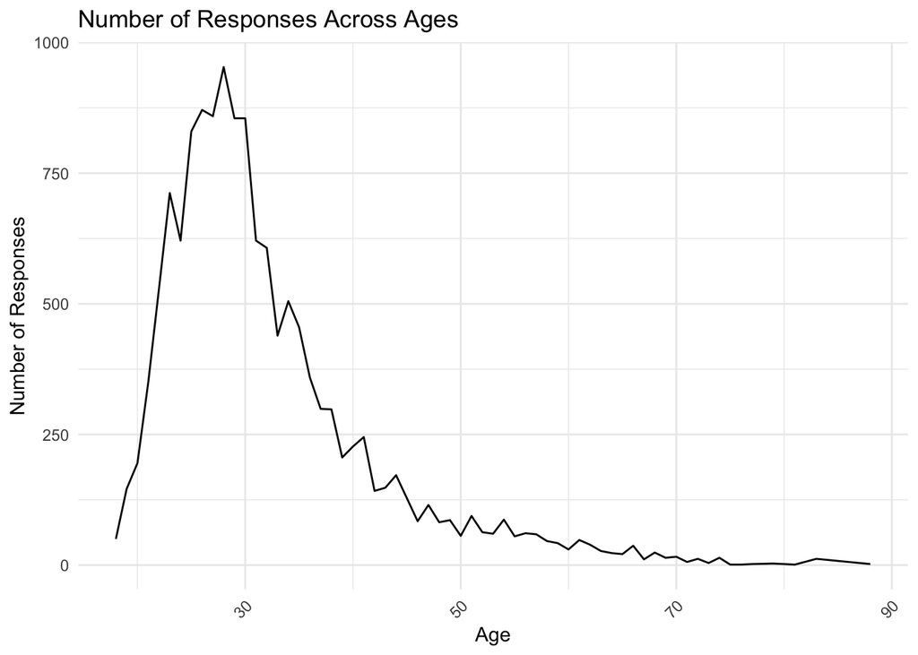

The above line graph, “Number of Resonses Across Ages”, there’s a noticeable surge in responses from individuals between the ages of 10s and 30s. This peak in responses in such ages may suggest a heighted awareness about sources of happiness during these formative years.

While Aristotle suggested that happiness is a matter of individual agency, it’s intriguing to see such a pronounced trend in younger ages. Could it be that younger individuals are more exploratory in their quest to define their happiness? Or perhap it could be the modern age—with its digital connectivity and platforms—has given the youth more avenues to express and reflect upon their joy.

To further delve into this, I am grouping the ages by 10s, investigating the categories of the responses to track the trend. Since the data did not contain any of those between 0-9, all the visulas and analysis do not show information about that group.

Following data shows a fascinating pattern.

```
## [1] 18
```

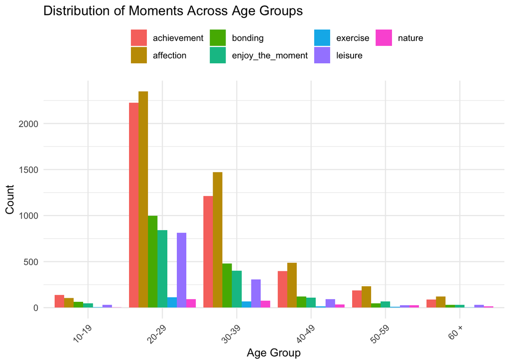

It is observed that the 20-29 age group is the most vocal, representing the highest number of responses, it’s the younger 10-19 age group that presents a unique perspective on happiness. Unlike their older age groups, this group derives their most pronounced moments of happiness from their achievements. This distinction is especially striking when juxtaposed with other age groups, where affection consistently emerges as the predominant source of joy.

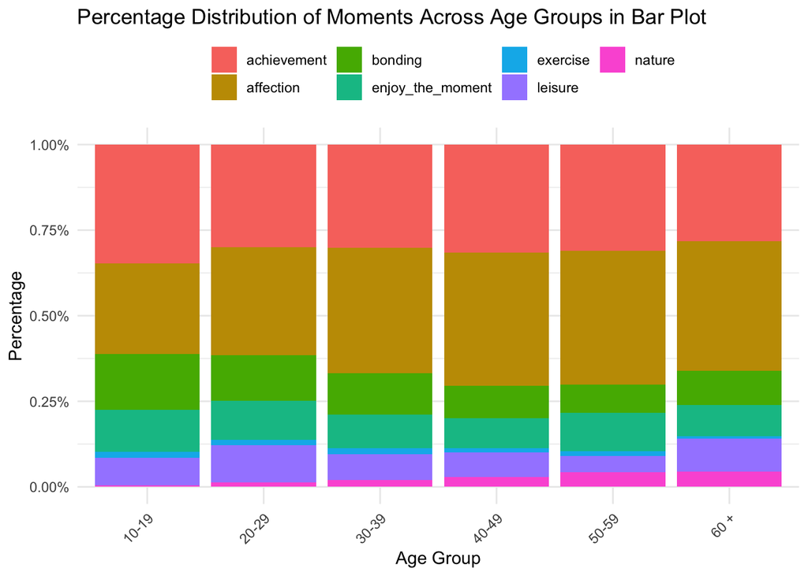

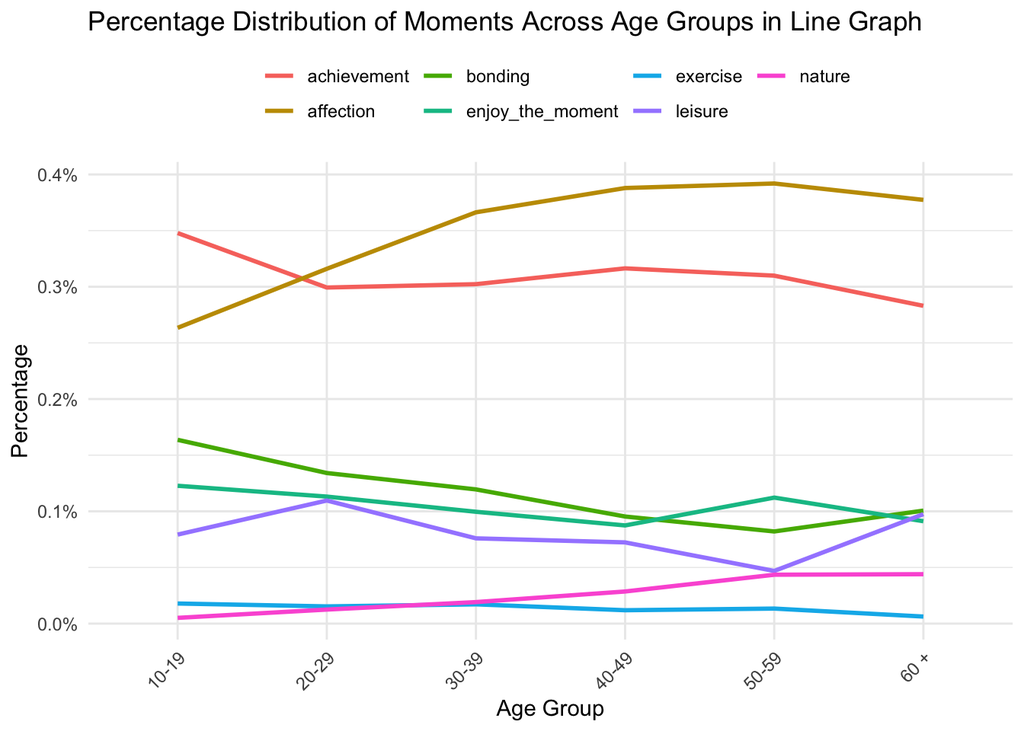

The above bar plot and line graph help to understand the trend of each moments that the responses were classified. Across age groups, a decline in the weight placed on achievement and bonding is evident as age increases. In contrast, the value attached to affection and nature tend to be increased as the age group got older. However, moments like exercise retain a steady importance throughout every age groups.

This leads to another quote from Friedrich Nietzche.

### “He who has a why to live can bear almost any how” - Friedrich Nietzche

The quote delivers an idea that individuals with a deeper purpose and meaning in their lives are better equipped to endure challenges, hardships, and even more. Indeed, as individuals journey through life, the reason behind-the deeper meaning on the purpose-upgrades. This could correspondingly lead to a question if the responses of happy moments by older aged groups to be somewhat more profound.

From the analysis above, it could be said that the responses from the older age groups like 60+ could be considered as being more profound. Drawing from the fact that the rise of moments such as ‘affection’ and ‘nature’ may mean the responses to be more profound compared to the younger aged groups with the emphasis on ‘achievement’ and ‘bonding’.

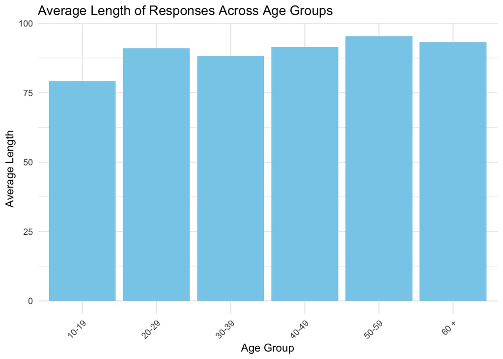

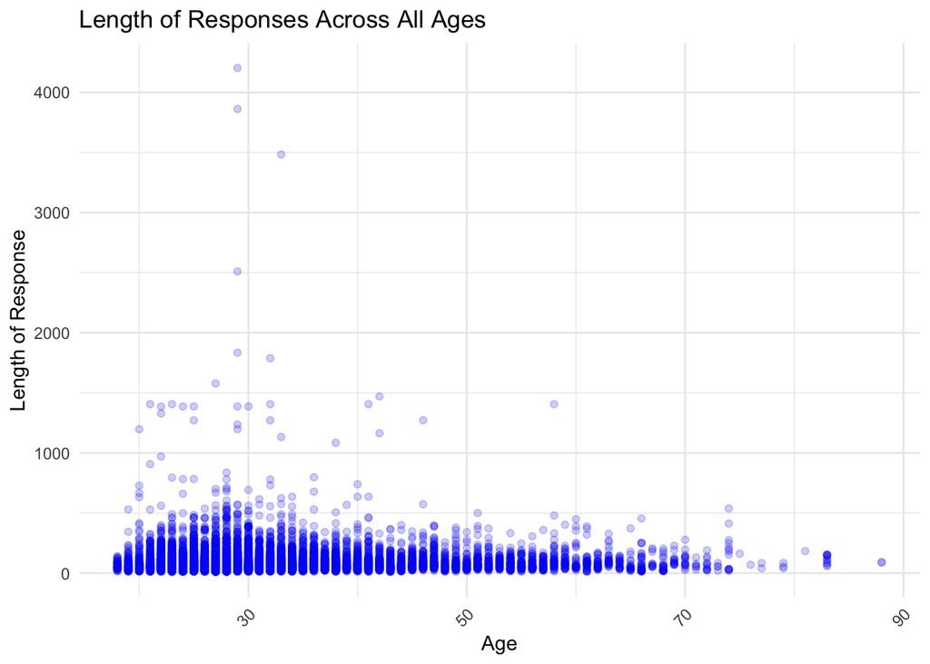

To further explore in this matter, I will be bringing up another quote from Søren Kierkegaard.

### “Life can oly be understood backward; but it must be lived forwards” - Søren Kierkegaard

Reflecting on the data of happy moment across different age groups, this quote encapsulates how people accumulate a rich tapestry of experiences to look back upon as they age. Also, it gives them deeper insights into the nature of life. To check this manner in real data, I focused on the length of the responses.

Intuitively, I expected the length to increase linearly with age, as individuals garner more life experiences to draw from. However, contrary to the assumption, the data conveys a nuanced result. Although there is a slight increase in response length, peaking at the age group of 50-59, it is a mere increase, and the length contracts for those above 60. The expected continuously increase doesn’t fully manifest in the oldest age group.

While the data suggests a correlation between age and the length of articulation, it doesn’t conclusively affirm depth or profundity. Longer responses might indicate more contemplation, but it’s worth noting that profundity isn’t solely dependent on word count. A brief, succinct reflection can be as profound as an extensive one.

Returning to Kierkegaard’s quotes, although the length of responses may add another layer to this exploration, it may not be sufficient enough to reflect the difference in depth of responses across different age groups. It is showing that the tapestry of human experience is rich, complex, and hard to be deciphered through a singular lens.

From here, to check upon the moments values, I have created word cloud for each of the age group, and again skipping age group 0-9 since there are no values in the data.

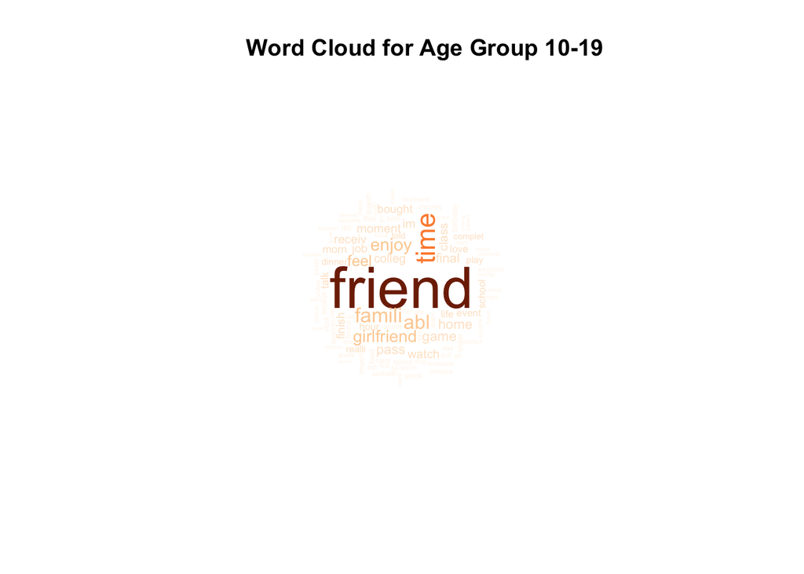

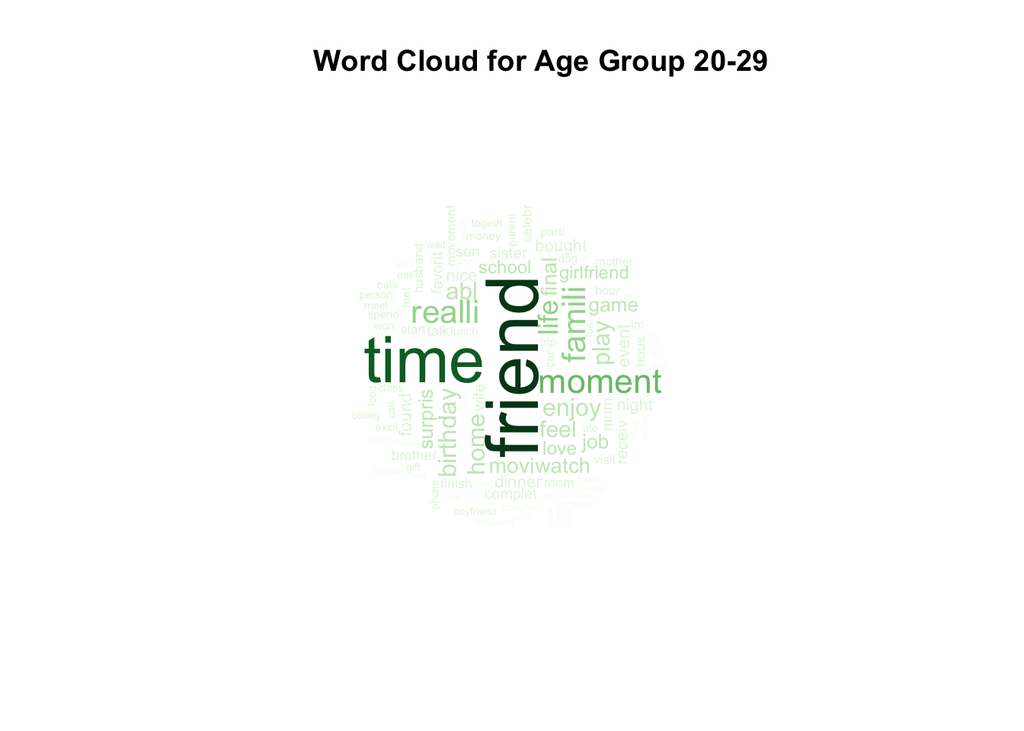

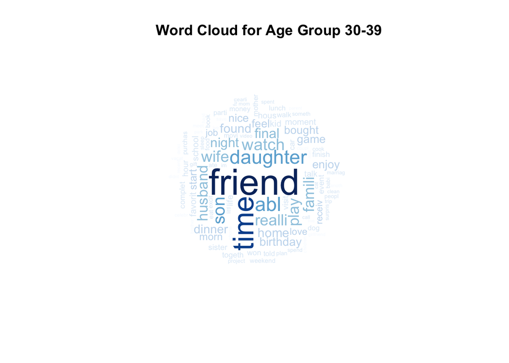

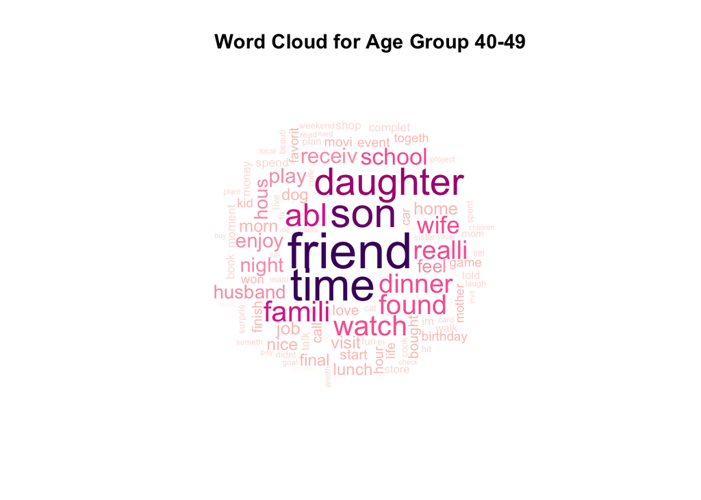

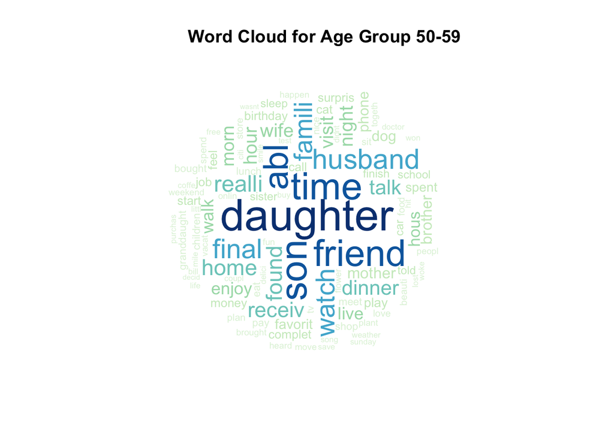

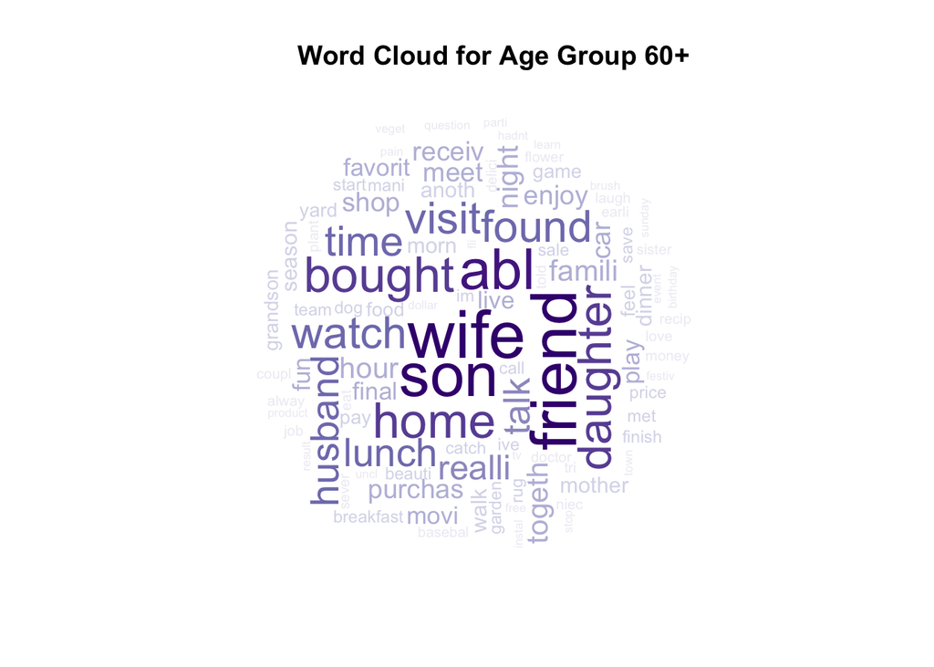

Drawing upon each of the word clouds, it is possible to perceive words like ‘friend’ and ‘time’ being significantly noticeable in all age groups. From age group 30-39, words like ‘daughter’ and ‘son’ starts to arise, eventually left with a vibrant and big section for the older aged groups.

Despite their similarity in some words, the difference in the prominence of the words clearly show how it could change proportion-wise, just like the results I got beforehand. Unlike 10-19 groups, the word cloud of 60+ is not only larger in size, but also the composition is much more fruitful. This data should help examining the quote from Friedrich Nietzche, since we are able to visualize the difference in amount considered when responding their happy moments.

### Conclusion

#### “Happiness depends upon ourselves.” - Aristotle

Through exploring HappyDB, happiness manifests in diverse ways across different age groups. Drawing from both the analysis of moments and word clouds, as individuals transition through life, their sources of happiness evolve—from the tangible achievements and bonds of youth to the intangible affections and appreciation of nature in older age. Overall, Aristotle’s perspective that the power to define our happiness is valid for the happiness is influenced by our life’s unique journey.

#### “He who has a why to live can bear almost any how” - Friedrich Nietzche

Suggesting that purpose underpins endurance, as people age, their happiness increasing draws from deeper meanings like affection and nature. As how the data shows, such shifts may well reflect the profound “whys” that come to the forefront as individuals navigate through life’s myriad “hows.”

#### “Life can only be understood backward; but it must be lived forwards,” - Søren Kierkegaard

Younger individuals find joy in the present, in their achievements and bonds, while older ones, with a tapestry of experiences to look back upon, derive happiness from moments of affection and nature’s embrace. The nuanced results on response lengths highlight that understanding life’s journey isn’t solely about the breadth of our words, but the depth of our feelings.